# 淘宝用户行为分析

```python
import numpy as np
import pandas as pd
import matplotlib.pyplot as plt
import seaborn as sns
```

```python
columns=["userid", 'itemid', 'categoryid', 'type', 'timestamp']
data = pd.read_csv('UserBehavior.csv',
                   names=columns,
                   chunksize=10000000,
                   iterator=True)
```

```python
dataframe = data.get_chunk(10000000)
```

```python
dataframe.head()
```

|  | userid | itemid | categoryid | type | timestamp |
| --- | --- | --- | --- | --- | --- |
| 0 | 1 | 2268318 | 2520377 | pv | 1511544070 |
| 1 | 1 | 2333346 | 2520771 | pv | 1511561733 |
| 2 | 1 | 2576651 | 149192 | pv | 1511572885 |
| 3 | 1 | 3830808 | 4181361 | pv | 1511593493 |
| 4 | 1 | 4365585 | 2520377 | pv | 1511596146 |

```python
dataframe.info()
```

```
<class 'pandas.core.frame.DataFrame'>
RangeIndex: 10000000 entries, 0 to 9999999
Data columns (total 5 columns):
userid        int64
itemid        int64
categoryid    int64
type          object
timestamp     int64
dtypes: int64(4), object(1)
memory usage: 381.5+ MB
```

```python
dataframe.isnull().sum()
```

```
userid        0
itemid        0
categoryid    0
type          0
timestamp     0
dtype: int64
```

# 把时间戳改为日期和时间

```python
import datetime
dataframe['time'] = pd.to_datetime(dataframe['timestamp'], unit='s')+datetime.timedelta(hours=8)

#数据集说明里指数据只包含2017.11.25-2017.12.3期间的数据，因此剔除在这段日期外的数据
begin = datetime.datetime.strptime('2017-11-25 00:00:00','%Y-%m-%d %H:%M:%S')
end = datetime.datetime.strptime('2017-12-3 23:59:59','%Y-%m-%d %H:%M:%S')
dataframe = dataframe[(dataframe.time>=begin)&(dataframe.time<=end)]
dataframe = dataframe.reset_index(drop=True)
```

```python
#进一步拓展日期的小时
dataframe['date'] = dataframe.time.dt.date
dataframe['hour'] = dataframe.time.dt.hour
```

```python
dataframe.drop('timestamp',inplace=True, axis=1)
```

```python
dataframe.head()
```

|  | userid | itemid | categoryid | type | time | date | hour |
| --- | --- | --- | --- | --- | --- | --- | --- |
| 0 | 1 | 2268318 | 2520377 | pv | 2017-11-25 01:21:10 | 2017-11-25 | 1 |
| 1 | 1 | 2333346 | 2520771 | pv | 2017-11-25 06:15:33 | 2017-11-25 | 6 |
| 2 | 1 | 2576651 | 149192 | pv | 2017-11-25 09:21:25 | 2017-11-25 | 9 |
| 3 | 1 | 3830808 | 4181361 | pv | 2017-11-25 15:04:53 | 2017-11-25 | 15 |
| 4 | 1 | 4365585 | 2520377 | pv | 2017-11-25 15:49:06 | 2017-11-25 | 15 |

# 用户行为分析

```python
pd.set_option('float_format', lambda x:'%.2f' %x)
```

```python
type_value = dataframe.type.value_counts()
```

```python
type_value
```

```
pv      8944510
cart     559132
fav      291657
buy      199147
Name: type, dtype: int64
```

```python
unique_user = dataframe.userid.nunique()
```

```python
type_df = pd.DataFrame([type_value, type_value/9, type_value/unique_user],
                       index = ['total','avg_day','avg_user'])
```

```python
type_df
```

|  | pv | cart | fav | buy |
| --- | --- | --- | --- | --- |
| total | 8944510.00 | 559132.00 | 291657.00 | 199147.00 |
| avg_day | 993834.44 | 62125.78 | 32406.33 | 22127.44 |
| avg_user | 91.45 | 5.72 | 2.98 | 2.04 |

```python
#每种行为下购买人数
type_df.loc['buying_user'] = dataframe[dataframe['userid'].isin(dataframe[dataframe['type']
                                                                          =='buy']['userid'])].type.value_counts()
```

```python
type_df
```

|  | pv | cart | fav | buy |
| --- | --- | --- | --- | --- |
| total | 8944510.00 | 559132.00 | 291657.00 | 199147.00 |
| avg_day | 993834.44 | 62125.78 | 32406.33 | 22127.44 |
| avg_user | 91.45 | 5.72 | 2.98 | 2.04 |
| buying_user | 6638346.00 | 432612.00 | 211633.00 | 199147.00 |

# 漏斗转化率分析

```python
pv_df = dataframe[dataframe['type']=='pv']
fav_df = dataframe[dataframe['type']=='fav']
cart_df = dataframe[dataframe['type']=='cart']
buy_df = dataframe[dataframe['type']=='buy']
```

```python
#路径1 点击，加购物车，购买
pv_cart_df = pd.merge(left=pv_df, right=cart_df, how='inner', on=['userid','itemid','categoryid'],
                     suffixes=('_pv','_cart'))
cart_buy_df = pd.merge(left=cart_df, right=buy_df, how='inner', on=['userid','itemid','categoryid'],
                     suffixes=('_cart','_buy'))
pv_cart_df.head()
```

|  | userid | itemid | categoryid | type_pv | time_pv | date_pv | hour_pv | type_cart | time_cart | date_cart | hour_cart |
| --- | --- | --- | --- | --- | --- | --- | --- | --- | --- | --- | --- |
| 0 | 1000 | 5120034 | 1051370 | pv | 2017-11-27 08:58:00 | 2017-11-27 | 8 | cart | 2017-11-25 00:47:14 | 2017-11-25 | 0 |
| 1 | 1000004 | 3999536 | 4756105 | pv | 2017-11-27 00:06:01 | 2017-11-27 | 0 | cart | 2017-11-25 09:03:40 | 2017-11-25 | 9 |
| 2 | 1000004 | 3999536 | 4756105 | pv | 2017-11-29 22:48:11 | 2017-11-29 | 22 | cart | 2017-11-25 09:03:40 | 2017-11-25 | 9 |
| 3 | 1000004 | 2980887 | 3607361 | pv | 2017-11-29 22:33:57 | 2017-11-29 | 22 | cart | 2017-11-26 12:14:31 | 2017-11-26 | 12 |
| 4 | 1000004 | 2980887 | 3607361 | pv | 2017-12-02 21:41:00 | 2017-12-02 | 21 | cart | 2017-11-26 12:14:31 | 2017-11-26 | 12 |

```python
#点击到加入购物车人数
count_pv_cart = pv_cart_df[pv_cart_df.time_pv < pv_cart_df.time_cart].userid.nunique()
count_pv_cart
```

```
40063
```

```python
#加入购物车到购买人数
count_cart_buy = cart_buy_df[cart_buy_df.time_cart < cart_buy_df.time_buy].userid.nunique()
count_cart_buy
```

```
22151
```

```python
#路径2 点击，收藏，购买
pv_fav_df = pd.merge(left=pv_df, right=fav_df, how='inner', on=['userid','itemid','categoryid'],
                     suffixes=('_pv','_fav'))
fav_buy_df = pd.merge(left=fav_df, right=buy_df, how='inner', on=['userid','itemid','categoryid'],
                     suffixes=('_fav','_buy'))
```

```python
#点击到收藏人数
count_pv_fav = pv_fav_df[pv_fav_df.time_pv < pv_fav_df.time_fav].userid.nunique()
count_pv_fav
```

```
18035
```

```python
#收藏到购买人数
count_fav_buy = fav_buy_df[fav_buy_df.time_fav < fav_buy_df.time_buy].userid.nunique()
count_fav_buy
```

```
8485
```

```python
#总用户到收藏和加购物车转化率
fav_cart_ratio = (count_pv_fav + count_pv_cart)/unique_user
print('收藏和加购物车转化率为:%.2f%%'%(fav_cart_ratio*100))
```

```
收藏和加购物车转化率为:59.40%
```

```python
#总用户到购买转化率
buy_ratio = (count_fav_buy + count_cart_buy)/unique_user
print('购买用户转化率为:%.2f%%'%(buy_ratio*100))
```

```
购买用户转化率为:31.32%
```

```python
from pyecharts.charts import Funnel
import pyecharts.options as opts

type_data_pair = [('点击',unique_user),
                 ('收藏和加购物车', count_pv_fav + count_pv_cart),
                 ('购买', count_fav_buy + count_cart_buy)]
funnel = (Funnel()
         .add('type',
             data_pair = type_data_pair,
             gap = 2,
             label_opts = opts.LabelOpts(position = 'top'),
             tooltip_opts = opts.TooltipOpts(is_show=True))
         .set_global_opts(title_opts = opts.TitleOpts(title='用户转化率',subtitle='点击，收藏/加购物车，购买'))
         )
funnel.render_notebook()
```

[output not shown]

# 从日期维度分析

```python
groupby_date = dataframe.groupby(by=dataframe.date)
dates = sorted(list(dict(dataframe['date'].value_counts()).keys()))
dates_df = pd.DataFrame(data=None, index =dates, columns=['pv','cart','fav','buy'])
dates_df
```

|  | pv | cart | fav | buy |
| --- | --- | --- | --- | --- |
| 2017-11-25 | NaN | NaN | NaN | NaN |
| 2017-11-26 | NaN | NaN | NaN | NaN |
| 2017-11-27 | NaN | NaN | NaN | NaN |
| 2017-11-28 | NaN | NaN | NaN | NaN |
| 2017-11-29 | NaN | NaN | NaN | NaN |
| 2017-11-30 | NaN | NaN | NaN | NaN |
| 2017-12-01 | NaN | NaN | NaN | NaN |
| 2017-12-02 | NaN | NaN | NaN | NaN |
| 2017-12-03 | NaN | NaN | NaN | NaN |

```python
for d in dates:
    dates_df.loc[d] = groupby_date.get_group(d).type.value_counts()

#对应的星期几
dates_df['weekday'] = [datetime.datetime.isoweekday(datetime.date(x.year, x.month, x.day)) for x in dates_df.index]

dates_df
```

|  | pv | cart | fav | buy | weekday |
| --- | --- | --- | --- | --- | --- |
| 2017-11-25 | 931880 | 56283 | 30168 | 19719 | 6 |
| 2017-11-26 | 952269 | 59469 | 31281 | 20211 | 7 |
| 2017-11-27 | 897421 | 55010 | 29723 | 22225 | 1 |
| 2017-11-28 | 883696 | 54194 | 29002 | 20996 | 2 |
| 2017-11-29 | 913153 | 55802 | 30030 | 21814 | 3 |
| 2017-11-30 | 929352 | 56722 | 30469 | 21731 | 4 |
| 2017-12-01 | 972109 | 62885 | 31048 | 20941 | 5 |
| 2017-12-02 | 1238785 | 80377 | 40210 | 25868 | 6 |
| 2017-12-03 | 1225845 | 78390 | 39726 | 25642 | 7 |

```python
from pyecharts.charts import Line

line = Line()
line.add_xaxis(xaxis_data = dates_df.index)
line.add_yaxis('pv',y_axis=dates_df['pv'],is_symbol_show=False)
line.add_yaxis('cart',y_axis=dates_df['cart'],is_symbol_show=False)
line.add_yaxis('fav',y_axis=dates_df['fav'],is_symbol_show=False)
line.add_yaxis('buy',y_axis=dates_df['buy'],is_symbol_show=False)
line.set_global_opts(title_opts=opts.TitleOpts(title='每日不同行为用户数',
                                              subtitle='2017/11/25-2017/12/03'),
                    tooltip_opts=opts.TooltipOpts(trigger='axis'),
                    toolbox_opts=opts.ToolboxOpts(is_show=True),
                    xaxis_opts=opts.AxisOpts(type_='category',boundary_gap=False))
line.render_notebook()
```

[output not shown]

# 从时间点维度分析

```python
groupby_hour = dataframe.groupby(by='hour')
hours = [x for x in range(0,24)]
hours_df = pd.DataFrame(data=None, index = hours, columns=['pv','cart','fav','buy'])
hours_df.head()
```

|  | pv | cart | fav | buy |
| --- | --- | --- | --- | --- |
| 0 | NaN | NaN | NaN | NaN |
| 1 | NaN | NaN | NaN | NaN |
| 2 | NaN | NaN | NaN | NaN |
| 3 | NaN | NaN | NaN | NaN |
| 4 | NaN | NaN | NaN | NaN |

```python
for h in hours:
    hours_df.loc[h] = groupby_hour.get_group(h).type.value_counts()
hours_df.head()
```

|  | pv | cart | fav | buy |
| --- | --- | --- | --- | --- |
| 0 | 299276 | 18333 | 10458 | 5507 |
| 1 | 137524 | 8531 | 4949 | 2158 |
| 2 | 75402 | 4455 | 2836 | 1192 |
| 3 | 51747 | 3271 | 2022 | 708 |
| 4 | 43917 | 2683 | 1584 | 610 |

```python
h_line =Line()
h_line.add_xaxis(xaxis_data=hours_df.index)
h_line.add_yaxis('pv',y_axis=hours_df['pv'],is_symbol_show=False)
h_line.add_yaxis('cart',y_axis=hours_df['cart'],is_symbol_show=False)
h_line.add_yaxis('fav',y_axis=hours_df['fav'],is_symbol_show=False)
h_line.add_yaxis('buy',y_axis=hours_df['buy'],is_symbol_show=False)
h_line.set_global_opts(title_opts=opts.TitleOpts(title='不同时段用户数'),
                      tooltip_opts = opts.TooltipOpts(trigger='axis'),
                      toolbox_opts=opts.ToolboxOpts(is_show=True),
                      xaxis_opts = opts.AxisOpts(boundary_gap=False))
h_line.render_notebook()
```

[output not shown]

# • 从日期维度看：

• 从仅有的数据来看，用户似乎会在周末比周中更加活跃，鉴于只有9天的数据，这条可能不准确。

# • 从时间点维度看：

• 不同时间点各行为（点击、加购物车、收藏、购买）走势基本相同。

• 晚上18：00-21:00期间用户迅速增加，到21:00-22:00用户最为活跃。

• 10:00到18:00期间用户行为有所波动，但基本保持一致。

• 上午10:00、下午13:00和15:00用户行为都有所增加，可能是用户在工作的中间时间摸鱼。

# 每日活跃用户、购买用户数及购买率

```python
#定义活跃用户
active_user_standard = 3
for d in dates:
    dates_df.loc[d,'uv'] = groupby_date.get_group(d).userid.nunique()
    dates_df.loc[d,'dau'] = (groupby_date.get_group(d).groupby(by='userid').size()>active_user_standard).value_counts()[True]
dates_df['au_rate'] = dates_df['dau']/dates_df['uv']
dates_df['buyer'] = dataframe[dataframe['type']=='buy'].groupby(by=['date','userid']).size().count(level=0)
dates_df['buyer_rate']=dates_df['buyer']/dates_df['uv']
dates_df['总用户人均单量'] = dates_df['buy']/dates_df['uv']
dates_df['付费用户人均单量'] = dates_df['buy']/dates_df['buyer']
dates_df
```

[output not shown]

- 每日用户中活跃用户au_rate保持在70%以上，可能是活跃用户的定义要求不够高
- 用户中的购买用户率buyer_rate也基本在19%左右不变
- 总用户人均单量在0.27-0.32之间，可以看到12-02号开始这个数下降明显，可能是活动吸引来更多的用户，但这批用户购买欲望不强
- 付费用户中平均每人单量在1.48-1.55之间，一样在12-02和12-03时有所下降，买的单数较少，也可能因为有活动所以集中购买

```python
#用户每天进行多少项操作
user_date_act = dataframe[['userid','date','type']].groupby(by=['userid','date']).count()

#操作数高于3的称为活跃用户，每个用户的活跃天数有多少
user_active_days_df = user_date_act[user_date_act['type'] > 3].count(level=0)

#活跃用户天数分布
user_act_days_dist = user_active_days_df['type'].value_counts().sort_index()
user_act_days_dist
```

```
0     1532
1     4631
2     8769
3    12029
4    13949
5    13907
6    13162
7    12235
8    10299
9     7297
Name: type, dtype: int64
```

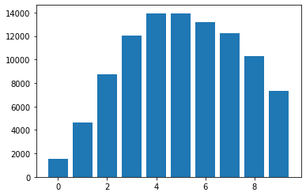

```python
plt.bar(range(len(user_act_days_dist)),user_act_days_dist)
plt.show()
```

可以看到活跃天数分布基本符合正态分布，活跃天数4-6天的用户最多。

# RFM分析

鉴于数据集没有金额，这里只做RF分析

```python
groupby_buy_userid = (dataframe[dataframe['type']=='buy']).groupby(by='userid')
RF = pd.DataFrame(index = groupby_buy_userid.groups.keys(),columns=['R','F'])

RF['F'] = groupby_buy_userid.type.count()
RF.head()
```

|  | R | F |
| --- | --- | --- |
| 27 | NaN | 2 |
| 43 | NaN | 6 |
| 100 | NaN | 8 |
| 117 | NaN | 10 |
| 119 | NaN | 3 |

```python
#最后一次购买时间
RF['last_time'] = groupby_buy_userid.time.max()
#12-04离最后一天购买相隔多少天
RF['R'] = (pd.to_datetime('2017-12-04')-RF['last_time']).dt.days
RF = RF[['R','F']]
RF.head()
```

|  | R | F |
| --- | --- | --- |
| 27 | 2 | 2 |
| 43 | 0 | 6 |
| 100 | 5 | 8 |
| 117 | 5 | 10 |
| 119 | 4 | 3 |

```python
#定义RF
def R_score(x):
    if 0<=x<=1:
        return 4
    elif 2<=x<=3:
        return 3
    elif 4<=x<=6:
        return 2
    elif 7<=x<=9:
        return 1
    else:
        return 0

def F_score(x):
    if x==1:
        return 1
    elif x==2:
        return 2
    elif x==3:
        return 3
    elif x==4:
        return 4
    else:
        return 0
```

```python
RF['R_score']=RF.R.map(R_score)
RF['F_score']=RF.F.map(R_score)
RF.head()
```

|  | R | F | R_score | F_score |
| --- | --- | --- | --- | --- |
| 27 | 2 | 2 | 3 | 3 |
| 43 | 0 | 6 | 4 | 2 |
| 100 | 5 | 8 | 2 | 1 |
| 117 | 5 | 10 | 2 | 0 |
| 119 | 4 | 3 | 2 | 3 |

```python
#对用户进行分类，RF得分分别大于均值的为1，小于均值的为0
RF['R_mean'] = (RF['R_score']>RF['R_score'].mean())*1
RF['F_mean'] = (RF['F_score']>RF['F_score'].mean())*1

def classification(tup):
    R_mean, F_mean = tup
    if R_mean ==1 and F_mean==1:
        return '重要价值客户'
    if R_mean ==1 and F_mean==0:
        return '一般用户'
    if R_mean ==0 and F_mean==1:
        return '重要挽留客户'
    if R_mean ==0 and F_mean==0:
        return '流失客户'
    else:
        return None

RF['用户分类'] = RF[['R_mean','F_mean']].apply(classification,axis=1)
RF.head()
```

|  | R | F | R_score | F_score | R_mean | F_mean | 用户分类 |
| --- | --- | --- | --- | --- | --- | --- | --- |
| 27 | 2 | 2 | 3 | 3 | 0 | 1 | 重要挽留客户 |
| 43 | 0 | 6 | 4 | 2 | 1 | 0 | 一般用户 |
| 100 | 5 | 8 | 2 | 1 | 0 | 0 | 流失客户 |
| 117 | 5 | 10 | 2 | 0 | 0 | 0 | 流失客户 |
| 119 | 4 | 3 | 2 | 3 | 0 | 1 | 重要挽留客户 |

```python
RF.用户分类.value_counts()
```

```
重要挽留客户    29729
重要价值客户    18439
一般用户      11830
流失客户       6454
Name: 用户分类, dtype: int64
```

```python
RF.用户分类.value_counts(1)
```

```
重要挽留客户   0.45
重要价值客户   0.28
一般用户     0.18
流失客户     0.10
Name: 用户分类, dtype: float64
```

*挽留客户（即相比平均值来说最近没买，但过去购买的次数较多的用户）占的比率最大，差不多为总体的一半，要增强用户黏性避免发展为流失*重要价值客户比一般用户多出十个百分点 *基于数据集只有9天的数据，在客户购买频次和Recency上做分析可能数据量不太足够，只能作为参考。